# Who is using Wikidata Query Service and how are they using it?

Mikhail Popov  
Discovery / Analysis  
Wikimedia Foundation

## Background

The Wikidata Query Service (WDQS) is designed to let users run queries on the data contained in Wikidata. The service uses *SPARQL Protocol and RDF Query Language* (SPARQL) as the query language.

## Statistics

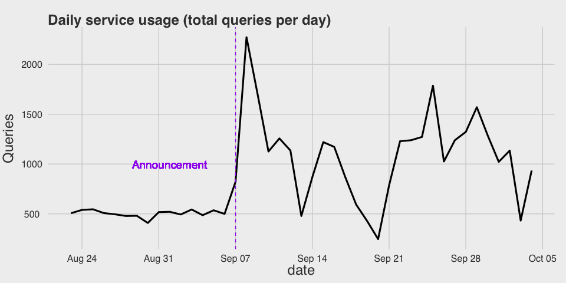

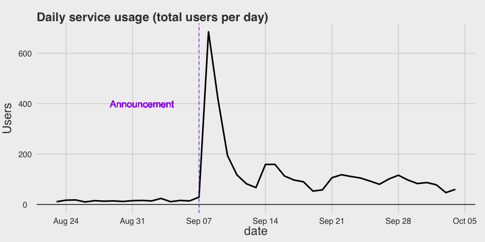

The number of users of the service has fallen since the announcement, vacillating at around 100 users per day in the recent weeks.

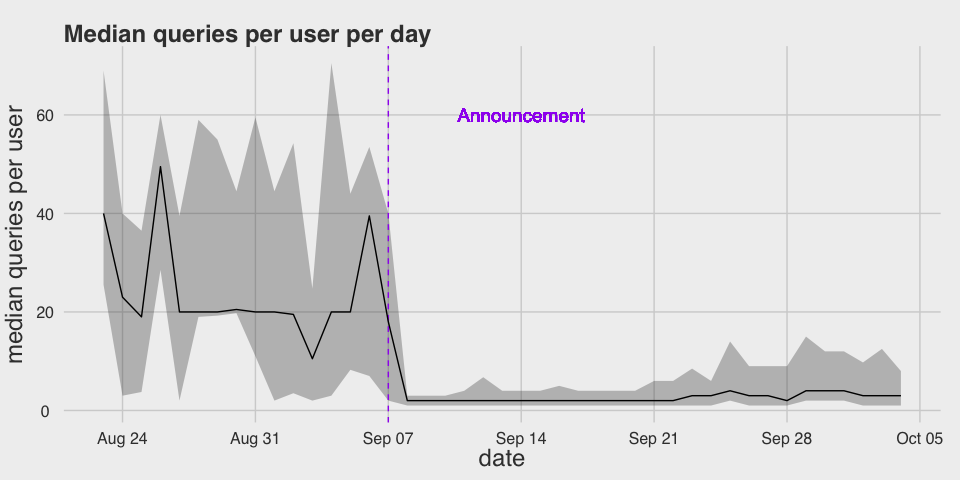

The lower and upper bounds represent the first and third quartiles (25% and 75%). Here we can see that the number of queries per user has stabilized a lot after the announcement, mostly because prior to the announcement the queries came from few bots testing the service.

WDQS users are a very geographically diverse bunch! In fact, 73 different countries[^1] were represented between August 23<sup>rd</sup> and October 4<sup>th</sup>.

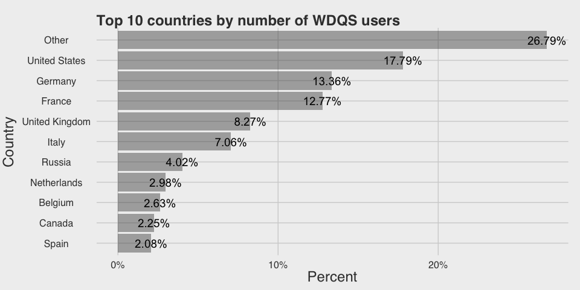

U.S., U.K., Germany, and France are the top-represented countries, with U.S. leading the pack.

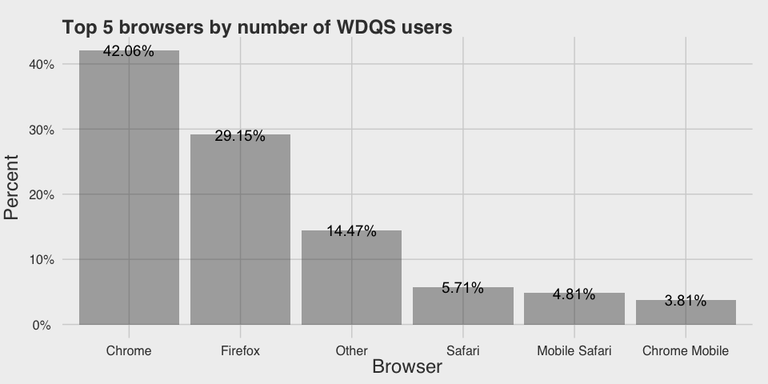

Chrome and Firefox are, unsurprisingly, WDQS users’ preferred browsers.

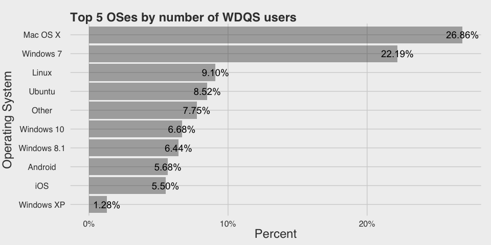

Windows 7 and Mac OS X users are by far the most popular operating systems among WDQS users.

### User-written queries vs provided example queries

Perhaps the biggest challenge of working with this dataset was the fact that a lot of the queries that our users ran were just sample queries we provide on query.wikidata.org or examples found on MediaWiki/Wikitech. Therefore, we put together a procedure for detecting whether a query is an example or not.

We were able to find a few queries and manually mark them as examples. Other queries that were perfect matches to these manually verified queries were marked as “definitely an example”.

#### Methods

First, we compiled a list of example queries, stripped out extraneous spaces (“condensed”), and cropped them using the maximum length of condensed user-submitted queries.

The procedure can be described as follows. For each user-submitted query $Q$:

1. Compute the Levenshtein distance $d_m$ between it and each of the $M$ example queries on file ($E_m$ for $m = 1, \ldots, M$), giving the minimal possibly weighted number of insertions, deletions and substitutions needed to transform the query into the example.
2. Calculate the maximum edit distance for each of the query-example query pairs. That is, if $|q|$ is the length of the query $q$, then the maximum edit distance is $\max\{|Q|, |E_m|\}$ for each $m = 1, \ldots, M$.
3. Normalize the computed Levenshtein distance by dividing it by the maximum edit distance. Let $d_m^N \in [0, 1]$ be this normalized distance.
4. Find the smallest normalized distance $\hat{d}$:
   $$\hat{d} = \min_{m = 1, \ldots, M} d_m^N$$
5. Calculate the “pseudo probability” $\hat{p} = 1 - \hat{d}$.
6. Calculate the “pseudo odds” $\hat{\theta} = \hat{p}/(1-\hat{p})$.
7. Then:
   1. If $\hat{\theta} \geq 4$, mark as “probably example”.
   2. If $2 \geq \hat{\theta} < 4$, mark as “maybe an example, maybe not”.
   3. And “definitely not an example” (or “definitely an example” as the case may be) otherwise.

That is, if a query is 4 or more times more likely to be an example than not, it makes sense to say it’s probably an example.

#### Results

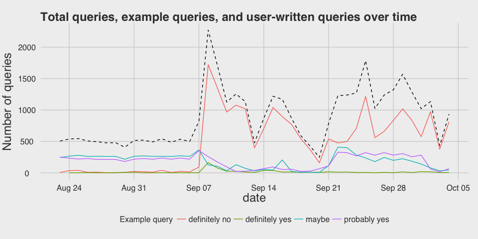

Total queries (black dashes) over time and how many were the sample queries we provided for demonstration.

| Is the query an example? | Total queries | % of total |
| --- | --- | --- |
| definitely no | 21487 | 56.48 |
| definitely yes | 651 | 1.71 |
| maybe | 7955 | 20.91 |
| probably yes | 7949 | 20.90 |

For many of the statistical break downs in this report, we will restrict ourselves to queries that are definitely not examples we provided.

### Tracking daily service usage in top countries

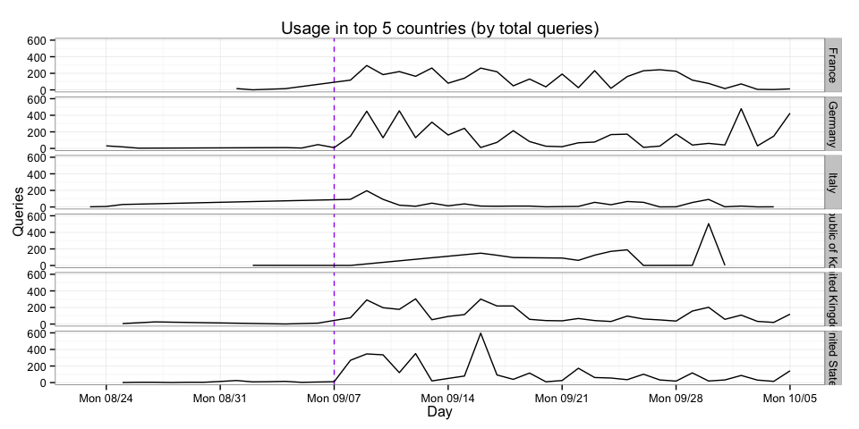

Varying patterns of WDQS usage by country (top 5 countries, over time). Purple dashes mark the public announcement.

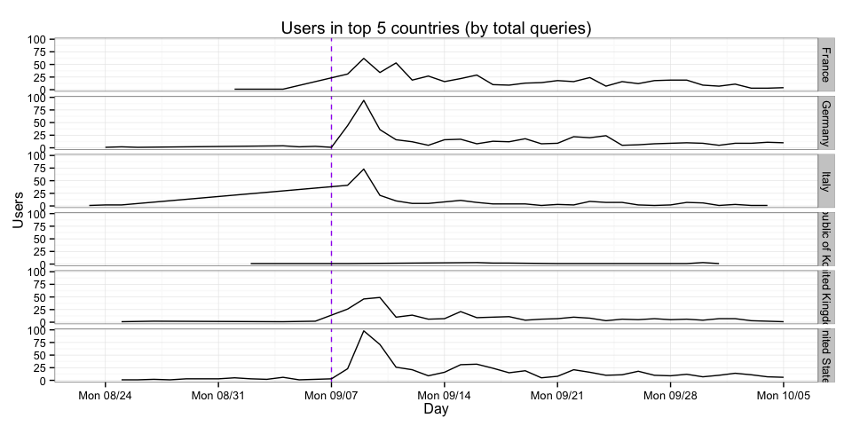

Varying patterns of WDQS unique users by country (top 5 countries, over time). Purple dashes mark the public announcement. What is very interesting is that South Korea is a top 5 country in usage but with barely any users.

### Who are our most active users?

#### Top 20 users by total queries

| total queries | os | browser_major | country |
| --- | --- | --- | --- |
| 2126 | Other | Other Other | Germany |
| 1340 | Other | Other Other | Unknown |
| 1339 | Other | Other Other | Unknown |
| 1281 | Other | Other Other | Unknown |
| 1222 | Other | Other Other | Unknown |
| 1163 | Other | Other Other | Unknown |
| 972 | Windows 7 | Chrome 45 | United Kingdom |
| 867 | Other | Other Other | Unknown |
| 794 | Other | Other Other | Unknown |
| 782 | Mac OS X | Safari 7 | United States |
| 702 | Other | Other Other | Unknown |
| 676 | Other | Other Other | Unknown |
| 627 | Other | Other Other | Unknown |
| 555 | Other | Other Other | Unknown |
| 473 | Other | Other Other | Unknown |
| 469 | Windows 7 | Firefox 40 | United Kingdom |
| 468 | Windows 7 | Chrome 45 | Republic of Korea |
| 465 | Other | Other Other | Unknown |
| 433 | Windows 8.1 | Firefox 41 | France |
| 422 | Windows XP | Firefox 40 | Switzerland |

#### Top 20 users by daily service usage

| median queries per day | os | browser_major | country |
| --- | --- | --- | --- |
| 172.0 | Windows 7 | Chrome 45 | Republic of Korea |
| 164.0 | Windows 8.1 | Chrome 45 | Republic of Korea |
| 126.0 | Windows 7 | Chrome 45 | United Kingdom |
| 110.0 | Windows 7 | Chrome 46 | United States |
| 103.0 | Other | Other Other | United States |
| 101.0 | Ubuntu | Chromium 44 | France |
| 99.0 | Linux | Firefox 42 | France |
| 97.0 | Windows 7 | Chrome 45 | Republic of Korea |
| 92.0 | Windows 7 | Chrome 45 | Republic of Korea |
| 90.0 | Windows 8.1 | Chrome 45 | Spain |
| 89.0 | Linux | Firefox 43 | United States |
| 85.5 | Windows 7 | Firefox 40 | United Kingdom |
| 82.0 | Windows 7 | Firefox 40 | Belgium |
| 81.0 | Windows 7 | Chrome 45 | Germany |
| 68.0 | Windows 10 | Chrome 45 | Republic of Korea |
| 67.0 | Other | Other Other | Unknown |
| 66.0 | Other | Other Other | Unknown |
| 62.0 | Mac OS X | Safari 7 | United States |
| 60.0 | Other | Other Other | Unknown |
| 60.0 | Windows 7 | Firefox 40 | Austria |

#### Users who made it to both lists

| total queries | median queries per day | os | browser_major | country |
| --- | --- | --- | --- | --- |
| 1340 | 60.0 | Other | Other Other | Unknown |
| 1281 | 67.0 | Other | Other Other | Unknown |
| 782 | 62.0 | Mac OS X | Safari 7 | United States |
| 469 | 85.5 | Windows 7 | Firefox 40 | United Kingdom |
| 468 | 172.0 | Windows 7 | Chrome 45 | Republic of Korea |

### Referrers

| url | total | % of total |
| --- | --- | --- |
| – | 13269 | 88.13 |
| https://query.wikidata.org/ | 661 | 4.39 |
| https://query.wikidata.org/#…QUERY… | 355 | 2.36 |
| https://www.wikidata.org/wiki/Wikidata:Data_access | 172 | 1.14 |
| https://www.facebook.com/gertruda | 70 | 0.46 |
| https://query.wikidata.org | 46 | 0.31 |
| https://tools.wmflabs.org/ppp-sparql/ | 37 | 0.25 |
| http://www.traackr.com/ | 29 | 0.19 |
| http://www.google.com/ | 28 | 0.19 |
| http://longurl.org | 26 | 0.17 |
| https://m.facebook.com/?_rdr | 26 | 0.17 |
| https://www.facebook.com/ | 24 | 0.16 |
| http://jamiembrown.com/ | 21 | 0.14 |
| http://tools.wmflabs.org/wdq2sparql/w2s.php | 20 | 0.13 |
| https://accounts.google.com/ServiceLogin?service=m… | 15 | 0.10 |
| https://www.rebelmouse.com/ | 15 | 0.10 |
| https://en.planet.wikimedia.org/ | 14 | 0.09 |
| https://www.google.com/ | 13 | 0.09 |
| https://www.google.com/?gws_rd=ssl#q=news | 10 | 0.07 |
| https://www.wikidata.org/wiki/Wikidata:Bistro | 10 | 0.07 |

| domain | total | % of total |
| --- | --- | --- |
| – | 13269 | 88.13 |
| query.wikidata.org | 1063 | 7.06 |
| www.wikidata.org | 192 | 1.28 |
| www.facebook.com | 103 | 0.68 |
| tools.wmflabs.org | 65 | 0.43 |
| www.google.com | 57 | 0.38 |
| www.traackr.com | 29 | 0.19 |
| m.facebook.com | 28 | 0.19 |
| longurl.org | 26 | 0.17 |
| jamiembrown.com | 21 | 0.14 |
| accounts.google.com | 18 | 0.12 |
| www.rebelmouse.com | 15 | 0.10 |
| en.planet.wikimedia.org | 14 | 0.09 |
| www.google.de | 13 | 0.09 |
| magnusmanske.de | 9 | 0.06 |
| www.google.it | 9 | 0.06 |
| it.wikisource.org | 8 | 0.05 |
| www.google.co.uk | 7 | 0.05 |
| www.google.nl | 7 | 0.05 |
| www.google.fr | 6 | 0.04 |

#### Daily visitors…

**…from ourselves:**

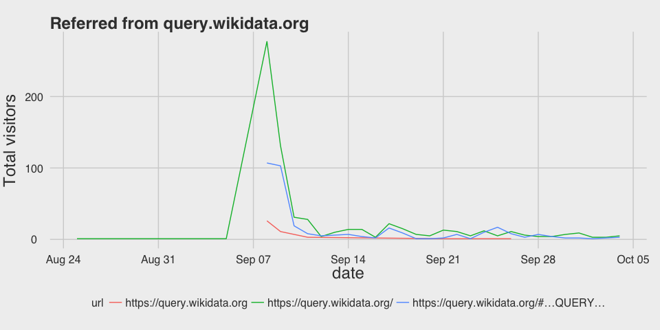

**…from others:**

[interactive chart not shown]

**Note** that this is an interactive graph like the ones we use in Discovery Dashboards. Mouse-over to see the values of the time series in the legend. You can also zoom in on a particular range. (Zoom out by double-clicking.)

**Legend:**

#### Top referrers (of query requests):

| referer | users |
| --- | --- |
| https://query.wikidata.org/ | 2563 |
| https://query.wikidata.org./ | 205 |
| - | 153 |
| http://demo.seco.tkk.fi/visu/ | 48 |
| https://query.wikidata.org/#PREFIX%20wik… | 30 |
| https://www.mediawiki.org/wiki/Wikidata_… | 24 |
| https://query.wikidata.org/#PREFIX%20wd%… | 10 |

The referers were shortened for privacy and space reasons as they contained queries.

## Queries

### Query lengths

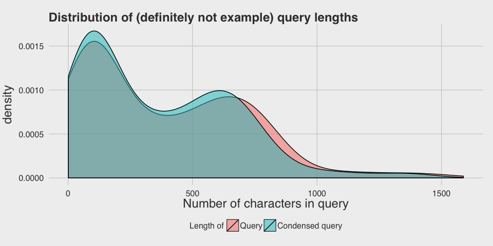

We can see multiple modes in the distribution of query lengths, which suggests that the distribution is a mixture of several distributions. The next step is to use a clustering algorithm to separate the distributions out into distinct groups. For this task, we chose a model-based clustering algorithm.

We performed model-based clustering on the log10-transformed character counts of condensed queries that were “definitely not” sample queries we provided. (Model-based clustering relies on Gaussian mixture models, so the log10 transformation was employed to correct for the right-skewness and make the data Normal.)

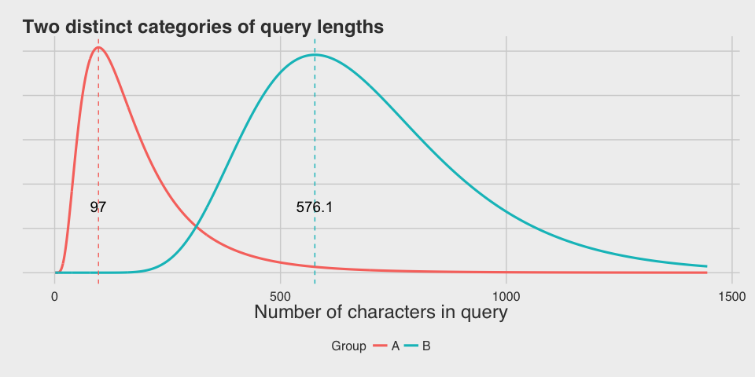

The most optimal model was a 2-component univariate mixture with unequal variances. The centers for the 2 clusters (on the raw scale) are: 97 and 576 characters.

### Example queries

#### Shortest queries

| a | _O_O | cpi | Django | Poland |
| --- | --- | --- | --- | --- |
| { | isis | house | PREFIX | ASK {} |
| l | Paris | turku | Fruits | iraq |
| GIS | Putin | Berlin | Hitman | {SPAQL |
| Q975 | qqq | Darwin | SELECT | wallera |

#### Some of the longer queries

```
http://tago01.inttech.flab.fujitsu.co.jp/lod4all/api/search.cgi?appID=xawsaykmcb&type=sparql&format=json&query=select+*+where++%7B%0A++++++++++++%7B%3Chttp%3A%2F%2Fja.dbpedia.org%2Fresource%2F%E6%9D%B1%E4%BA%AC%3E+%3Fp+%3Fo+.+%7D%0AUNION+%7B+%3Chttp%3A%2F%2Fja.dbpedia.org%2Fresource%2FTokyo%3E+%3Fp+…

======================

DESCRIBE <https://be-tarask.wikipedia.org/wiki/%D0%9A%D0%B0%D1%82%D1%8D%D0%B3%D0%BE%D1%80%D1%8B%D1%8F%3A%D0%9A%D0%BE%D1%81%D0%BC%D0%B0%D1%81>

======================

DESCRIBE <https://mk.wikipedia.org/wiki/%D0%9A%D0%B0%D1%82%D0%B5%D0%B3%D0%BE%D1%80%D0%B8%D1%98%D0%B0%3A%D0%92%D1%81%D0%B5%D0%BB%D0%B5%D0%BD%D0%B0>
```

#### Some of the longer queries (part 2)

```
PREFIX p: <http://www.wikidata.org/prop/>
PREFIX q: <http://www.wikidata.org/prop/qualifier/>
PREFIX wikibase: <http://wikiba.se/ontology#>
PREFIX wdt: <http://www.wikidata.org/prop/direct/>
prefix wd: <http://www.wikidata.org/entity/>
SELECT DISTINCT ?s WHERE {
  ?s p:P551 ?st .
  ?st q:P580 ?t .
  OPTIONAL { ?st q:P582 ?t2 }
  ?st wikibase:rank wikibase:NormalRank.
  FILTER(!bound(?t2))
  ?s p:P551 ?st2 .
  FILTER(?st2 != ?st)
  OPTIONAL { ?s wdt:P570 ?d }
  FILTER(!bound(?d))
  ?st2 wikibase:rank wikibase:NormalRank.
  FILTER NOT EXISTS { VALUES ?s { wd:Q49601 wd:Q2832892 wd:Q5249867 wd:Q6174253 wd:Q11994910 wd:Q18588524 wd:Q18582082 wd:Q18643319 wd:Q17100851 wd:Q20820956 wd:Q360 wd:Q6294 wd:Q19799971 wd:Q37876 wd:Q2835169 wd:Q16247359 wd:Q18643303 wd:Q15407925 wd:Q6783051 wd:Q18676928 wd:Q11982912 wd:Q18587441 …
} LIMIT 10

======================


PREFIX p: <http://www.wikidata.org/prop/>
PREFIX q: <http://www.wikidata.org/prop/qualifier/>
PREFIX wikibase: <http://wikiba.se/ontology#>
PREFIX wdt: <http://www.wikidata.org/prop/direct/>
prefix wd: <http://www.wikidata.org/entity/>
SELECT DISTINCT ?s WHERE {
  ?s p:P551 ?st .
  ?st q:P580 ?t .
  OPTIONAL { ?st q:P582 ?t2 }
  ?st wikibase:rank wikibase:NormalRank.
  FILTER(!bound(?t2))
  ?s p:P551 ?st2 .
  FILTER(?st2 != ?st)
  OPTIONAL { ?s wdt:P570 ?d }
  FILTER(!bound(?d))
  ?st2 wikibase:rank wikibase:NormalRank.
  FILTER NOT EXISTS { VALUES ?s { wd:Q49601 wd:Q2832892 wd:Q5249867 wd:Q6174253 wd:Q11994910 wd:Q18588524 wd:Q18582082 wd:Q18643319 wd:Q17100851 wd:Q20820956 wd:Q360 wd:Q6294 wd:Q19799971 wd:Q37876 wd:Q2835169 wd:Q16247359 wd:Q18643303 wd:Q15407925 wd:Q6783051 wd:Q18676928 wd:Q11982912 wd:Q18587441 …
} LIMIT 10
```

[output cut: 15 more lines]

```
PREFIX rdfs: <http://www.w3.org/2000/01/rdf-schema#>PREFIX wd: <http://www.wikidata.org/entity/>
PREFIX wdt: <http://www.wikidata.org/prop/direct/>
PREFIX wikibase: <http://wikiba.se/ontology#>
PREFIX p: <http://www.wikidata.org/prop/>
PREFIX v: <http://www.wikidata.org/prop/statement/>
PREFIX q: <http://www.wikidata.org/prop/qualifier/>
PREFIX rdfs: <http://www.w3.org/2000/01/rdf-schema#>PREFIX wd: <http://www.wikidata.org/entity/>
PREFIX wdt: <http://www.wikidata.org/prop/direct/>
PREFIX wikibase: <http://wikiba.se/ontology#>
PREFIX p: <http://www.wikidata.org/prop/>
PREFIX v: <http://www.wikidata.org/prop/statement/>
PREFIX q: <http://www.wikidata.org/prop/qualifier/>
PREFIX rdfs: <http://www.w3.org/2000/01/rdf-schema#>
select ?x ?y ?z WHERE {
w
```

#### Examples of Category “A” queries:

```
PREFIX wd: <http://www.wikidata.org/entity/>
PREFIX wdt: <http://www.wikidata.org/prop/direct/>
PREFIX rdfs: <http://www.w3.org/2000/01/rdf-schema#>
SELECT ?s ?sl ?o WHERE {
   ?s wdt:P2005 ?o .
  ?s rdfs:label ?sl .
  FILTER (lang(?sl)='ko')
 }limit 1000
======================

PREFIX wikibase: <http://wikiba.se/ontology#>
PREFIX rdfs: <http://www.w3.org/2000/01/rdf-schema#>

SELECT ?p ?o
WHERE {<http://www.wikidata.org/prop/direct/P354> ?p ?o}

======================

PREFIX wd: <http://www.wikidata.org/entity/>
PREFIX wdt: <http://www.wikidata.org/prop/direct/>
PREFIX rdfs: <http://www.w3.org/2000/01/rdf-schema#>
SELECT ?s ?sl ?o WHERE {
   ?s wdt:P351 ?o .
  ?s rdfs:label ?sl .
  FILTER (lang(?sl)='en')
 }limit 1000
```

#### Examples of Category “B” queries:

```
PREFIX p: <http://www.wikidata.org/prop/>
PREFIX q: <http://www.wikidata.org/prop/qualifier/>
PREFIX wikibase: <http://wikiba.se/ontology#>
PREFIX wdt: <http://www.wikidata.org/prop/direct/>
prefix wd: <http://www.wikidata.org/entity/>
SELECT DISTINCT ?s WHERE {
  ?s p:P551 ?st .
  ?st q:P580 ?t .
  OPTIONAL { ?st q:P582 ?t2 }
  ?st wikibase:rank wikibase:NormalRank.
  FILTER(!bound(?t2))
  ?s p:P551 ?st2 .
  FILTER(?st2 != ?st)
  OPTIONAL { ?s wdt:P570 ?d }
  FILTER(!bound(?d))
  ?st2 wikibase:rank wikibase:NormalRank.
  FILTER NOT EXISTS { VALUES ?s { wd:Q49601 wd:Q2832892 wd:Q5249867 wd:Q6174253 wd:Q11994910 wd:Q18588524 wd:Q18582082 wd:Q18643319 wd:Q17100851 wd:Q20820956 wd:Q360 wd:Q6294 wd:Q19799971 wd:Q37876 wd:Q2835169 wd:Q16247359 wd:Q18643303 wd:Q15407925 wd:Q6783051 wd:Q18676928 wd:Q11982912 wd:Q18587441 …
} LIMIT 10

======================

PREFIX wd: <http://www.wikidata.org/entity/>
PREFIX wdt: <http://www.wikidata.org/prop/direct/>
PREFIX wikibase: <http://wikiba.se/ontology#>
PREFIX p: <http://www.wikidata.org/prop/>
PREFIX v: <http://www.wikidata.org/prop/statement/>
PREFIX q: <http://www.wikidata.org/prop/qualifier/>
PREFIX rdfs: <http://www.w3.org/2000/01/rdf-schema#>

SELECT ?tl ?coord ?b ?lat ?long WHERE {
?t wdt:P31 wd:Q484170 .
    ?t wdt:P625 ?coord .
?t p:P625 ?a .
  ?a v:P625 ?c .
      ?c wikibase:geoLatitude ?lat .
    ?c wikibase:geoLongitude ?long .


  OPTIONAL {
        ?t rdfs:label ?tl filter (lang(?tl) = "fr") .
    }

}
ORDER BY ASC(?lat)
LIMIT 100
```

## Discussion

### Partial Queries

One of the bigger challenges encountered in this analysis was the fact that queries were cropped. When the user executes a query, their query is passed via GET, and is saved in Varnish as an encoded `uri_path`. Varnish, however, has a character limit, so the encoded queries get cropped. Therefore, when we decode the queries, the end result is also cropped. So a lot of the queries in this dataset were partial queries.

### Example Matching

Another issue (and this may be actually be the biggest issue) is that many of the queries are sample queries found on various WDQS-related MediaWiki/Wikitech articles. We (read: I) had to compile together as many of the example queries as we could and then perform approximate string matching to separate the queries that are user-written from the ones that are probably examples.

The process we employed was ad-hoc, not very robust, and highly dubious, but not entirely unreasonable. We recommend collaborating with our language expert (read: Trey) to develop a more robust methodology for detecting when the query submitted matches an example query we have on file.

Furthermore, for the sake of time, we did not include example queries from other languages in our initial compilation of examples. Some of the queries that were deemed “definitely not an example” actually WERE most definitely examples written in French.

## Acknowledgements

We would like to thank Trey Jones for his advice in dealing with approximate string matching, and Oliver Keyes for his review of this report and helpful feedback.

## References

- [*Wikidata query service* on MediaWiki](https://www.mediawiki.org/wiki/Wikidata_query_service) and [WDQS User Manual](https://www.mediawiki.org/wiki/Wikidata_query_service/User_Manual)
- [*SPARQL* on Wikipedia](https://en.wikipedia.org/wiki/SPARQL)
- [**mclust**](http://www.stat.washington.edu/mclust/): Normal Mixture Modeling for Model-Based Clustering, Classification, and Density Estimation by Fraley, C. and [Raftery, A.](https://en.wikipedia.org/wiki/Adrian_Raftery)
[^1]: The countries are: Algeria, Angola, Argentina, Armenia, Australia, Austria, Azerbaijan, Belarus, Belgium, Brazil, Bulgaria, Cambodia, Canada, Chile, China, Colombia, Croatia, Czech Republic, Denmark, Ecuador, Egypt, Estonia, Finland, France, Germany, Ghana, Greece, Guadeloupe, Hungary, India, Indonesia, Iran, Ireland, Israel, Italy, Japan, Latvia, Luxembourg, Malaysia, Mali, Malta, Martinique, Mexico, Montenegro, Nepal, Netherlands, New Zealand, Norway, Poland, Portugal, Qatar, Republic of Korea, Romania, Russia, Saudi Arabia, Serbia, Singapore, Slovak Republic, Slovenia, South Africa, Spain, Sri Lanka, Sweden, Switzerland, Taiwan, Thailand, Turkey, Ukraine, United Kingdom, United States, Uruguay, Venezuela, and Vietnam.